# Project 2: Modeling, Testing, and Predicting

- **5. (40 pts)** Perform a logistic regression predicting a binary categorical variable (if you don’t have one, make/get one) from at least two explanatory variables (interaction not necessary).
  - Interpret coefficient estimates in context (10)
  - Report a confusion matrix for your logistic regression (2)
  - Compute and discuss the Accuracy, Sensitivity (TPR), Specificity (TNR), and Recall (PPV) of your model (5)
  - Using ggplot, plot density of log-odds (logit) by your binary outcome variable (3)
  - Generate an ROC curve (plot) and calculate AUC (either manually or with a package); interpret (10)
  - Perform 10-fold (or repeated random sub-sampling) CV and report average out-of-sample Accuracy, Sensitivity, and Recall (10)

```r
library(plotROC)
library(glmnet)
social<-social%>%dplyr::select(-psi_c,-affect_c)
social5 <- social %>% mutate(y = ifelse(gender == "female", 1, 0))
fit5<-glm(y~age + psi, family="binomial", data=social5)
coeftest(fit5)
```

```
##
## z test of coefficients:
##
## Estimate Std. Error z value Pr(>|z|)
## (Intercept) 0.595749 1.213060 0.4911 0.62335
## age21-24 0.256087 0.553074 0.4630 0.64335
## age25-30 0.467230 1.154648 0.4047 0.68573
## age31-40 -1.766909 0.935896 -1.8879 0.05904 .
## age40+ 0.024245 1.209515 0.0200 0.98401
## psi 0.043900 0.102036 0.4302 0.66702
## ---
## Signif. codes: 0 '***' 0.001 '**' 0.01 '*' 0.05 '.' 0.1
' ' 1
```

```r
exp(0.256087)
```

```
## [1] 1.291865
```

```r
exp(0.467230)
```

```
## [1] 1.595568
```

```r
exp(-1.766909)
```

```
## [1] 0.1708603
```

```r
exp( 0.024245)
```

```
## [1] 1.024541
```

```r
exp(0.043900)
```

```
## [1] 1.044878
```

```r
#confusion matrix
prob<-predict(fit5,type="response")
table(predict=as.numeric(prob>.5),truth=social5$y)%>%addmargins
```

```
##        truth
## predict  0  1 Sum
##     0    4  2   6
##     1   20 69  89
##     Sum 24 71  95
```

```r
69/71 #tpr
```

```
## [1] 0.971831
```

```r
4/24 #tnr
```

```
## [1] 0.1666667
```

```r
69/89 #ppv
```

```
## [1] 0.7752809
```

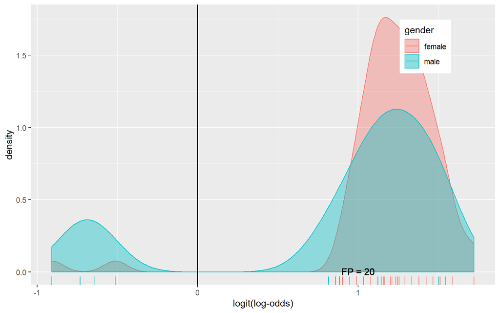

```r
#plot
social5$logit<-predict(fit5,type="link")
social5%>%ggplot()+geom_density(aes(logit,color=gender,fill=gender), alpha=.4)+
  theme(legend.position=c(.85,.85))+
  geom_vline(xintercept=0)+xlab("logit(log-odds)")+
  geom_rug(aes(logit,color=gender))+
  geom_text(x=-5,y=.07,label="TN = 4")+
  geom_text(x=-1.75,y=.008,label="FN = 2")+
  geom_text(x=1,y=.006,label="FP = 20")+
  geom_text(x=5,y=.04,label="TP = 69")
```

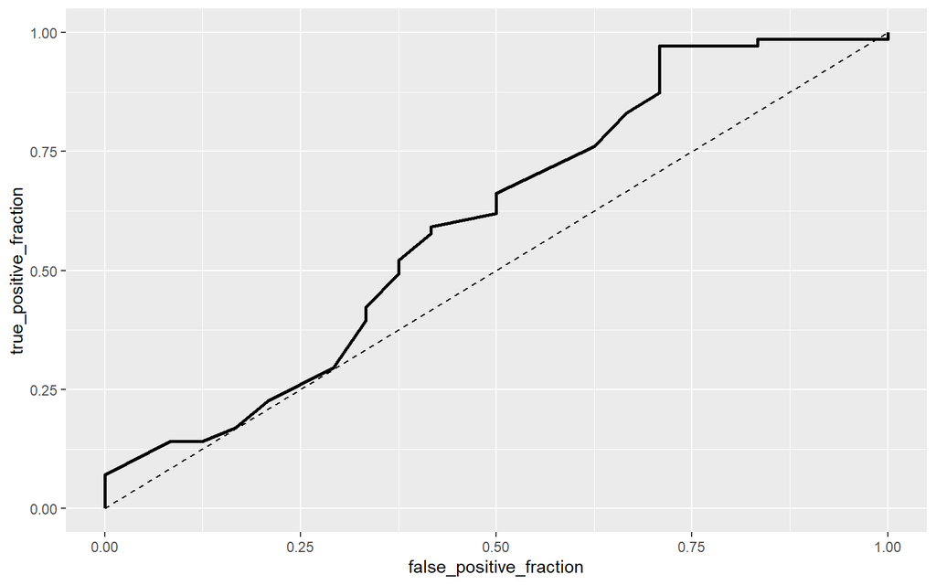

```r
#roc curve and auc
pred <- ifelse(prob > 0.5, 1, 0)
ROCplot <- ggplot(social5) + geom_roc(aes(d = y, m = prob), n.cuts = 0) +geom_segment(aes(x = 0, xend = 1, y = 0, yend = 1), lty = 2)
ROCplot
```

```r
calc_auc(ROCplot)
```

```
##   PANEL group       AUC
## 1     1    -1 0.6012324
```

```r
#10 fold
class_diag<-function(probs,truth){

  if(is.numeric(truth)==FALSE & is.logical(truth)==FALSE) truth<-as.numeric(truth)-1

  tab<-table(factor(probs>.5,levels=c("FALSE","TRUE")),truth)
  prediction<-ifelse(probs>.5,1,0)
  acc=mean(truth==prediction)
  sens=mean(prediction[truth==1]==1)
  spec=mean(prediction[truth==0]==0)
  ppv=mean(truth[prediction==1]==1)

  #CALCULATE EXACT AUC
  ord<-order(probs, decreasing=TRUE)
  probs <- probs[ord]; truth <- truth[ord]

  TPR=cumsum(truth)/max(1,sum(truth))
  FPR=cumsum(!truth)/max(1,sum(!truth))

  dup<-c(probs[-1]>=probs[-length(probs)], FALSE)
  TPR<-c(0,TPR[!dup],1); FPR<-c(0,FPR[!dup],1)

  n <- length(TPR)
  auc<- sum( ((TPR[-1]+TPR[-n])/2) * (FPR[-1]-FPR[-n]) )

  data.frame(acc,sens,spec,ppv,auc)
}

set.seed(1234)
k=10
data<-social5[sample(nrow(social5)),]
folds<-cut(seq(1:nrow(social5)),breaks=k,labels=F)
diags<-NULL
for(i in 1:k){
  train<-data[folds!=i,]
  test<-data[folds==i,]
  truth<-test$y
  fit5<-glm(y~age + psi, data=train, family="binomial")
  probs<-predict(fit5,newdata = test,type="response")
  diags<-rbind(diags,class_diag(probs,truth))}

summarize_all(diags,mean)
```

```
##         acc      sens spec       ppv       auc
## 1 0.7577778 0.9746032  NaN 0.7679365 0.5315675
```